# Kompetensförsörjning i Dalarna

# 4 Arbetsmarknaden i Dalarna

En väl fungerande arbetsmarknad kännetecknas bland annat av att många arbetar, att många arbetar med vad de är utbildade till och att det inte råder någon större brist på kompetens. En arbetsmarknad med dessa kännetecken kan sannolikt hantera såväl kriser i samhället, som de utmaningar som arbetsmarknaden ställs inför i framtiden.

## 4.1 Sysselsättningsgraden

Sysselsättningsgraden, det vill säga i vilken utsträckning människor i arbetsför ålder (20-64 år) arbetar, skiljer sig framförallt åt mellan inrikes och utrikes födda. Sysselsättningsgraden bland utrikes födda är lägre än sysselsättningsgraden för inrikes födda i samtliga svenska län. Det finns även skillnader mellan kvinnor och män.

För inrikes födda, det vänstra diagrammet i figur 32 nedan, är sysselsättningsgraden för båda könen ungefär lika hög. Variationen i sysselsättningsgrad mellan länen är även den ganska liten, vilket ger små skillnader mot riksgenomsnittet.

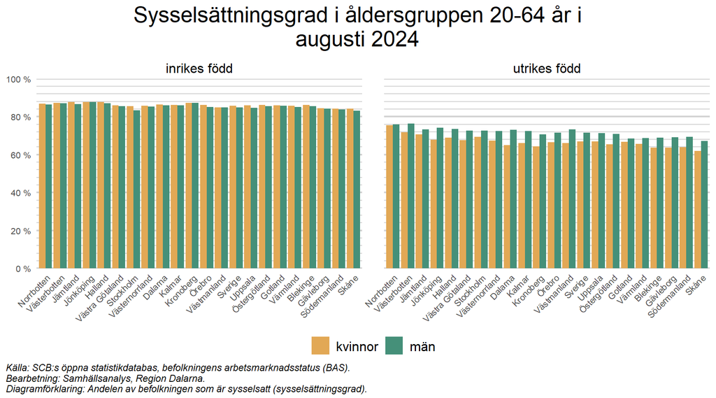

Figur 32.

Något som behöver tas hänsyn till vid en analys av sysselsättningsgraden bland utrikes födda är hur lång tid personerna har varit i Sverige, samt vilken utbildningsnivå de har. För en djupare diskussion runt detta, se Region Dalarnas rapport [“Kvinnor och män i Dalarna”](https://region-dalarna.github.io/kvinnor_man_i_Dalarna/).

Vad gäller sysselsättningsgrad uppvisar kommunerna i Dalarna ett liknande mönster som länen på nationell nivå. Gruppen inrikes födda har en högre sysselsättningsgrad i samtliga kommuner i Dalarna jämfört med utrikes födda. Även här är sysselsättningsgraden för inrikes födda kvinnor och män ungefär lika hög. För utrikes födda är det däremot stora skillnader mellan kvinnor och män, men också mellan olika kommuner. I linje med den nationella bilden är sysselsättningsgraden högre för gruppen utrikes födda män än för utrikes födda kvinnor.

Sysselsättningsgraden för utrikes födda män skiljer sig dock åt mellan kommuner där den högsta sysselsättningsgraden finns i Leksand (cirka 80 procent) och den lägsta i Smedjebacken (cirka 66 procent).

Skillnaderna mellan utrikes födda kvinnor och män är mer synliga mellan kommuner i Dalarna än när länen som helhet jämförs. Mora har den högsta sysselsättningsgraden för gruppen utrikes födda kvinnor, cirka 76 procent, och ligger klart över genomsnittet för Dalarnas län (knappt 65 procent). Samtidigt är sysselsättningsgraden bland utrikes födda kvinnor i Avesta kommun bara 59 procent.

Värt att notera är att en del av skillnaden i utrikes föddas sysselsättningsgrad mellan kommunerna i Dalarna sannolikt kan förklaras av skillnader i antalet personer som invandrade under åren runt flyktingkrisen 2015. Exempelvis var Avesta, Ludvika och Hedemora de tre kommuner som hade högst invandring i förhållande till folkmängd under 2015, 2016 och 2017.

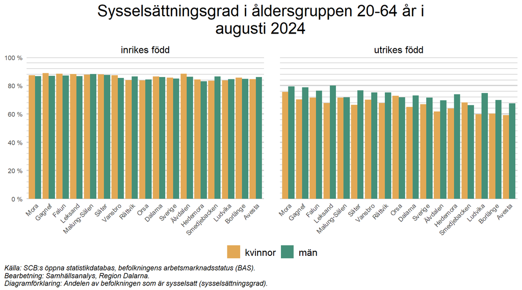

Figur 33.

Över tid har sysselsättningsgraden för personer i arbetsför ålder i Dalarna ökat bland både kvinnor och män. Sedan 1993 har andelen ökat från cirka 70 procent till drygt 80 procent för kvinnor och 84 procent för män.

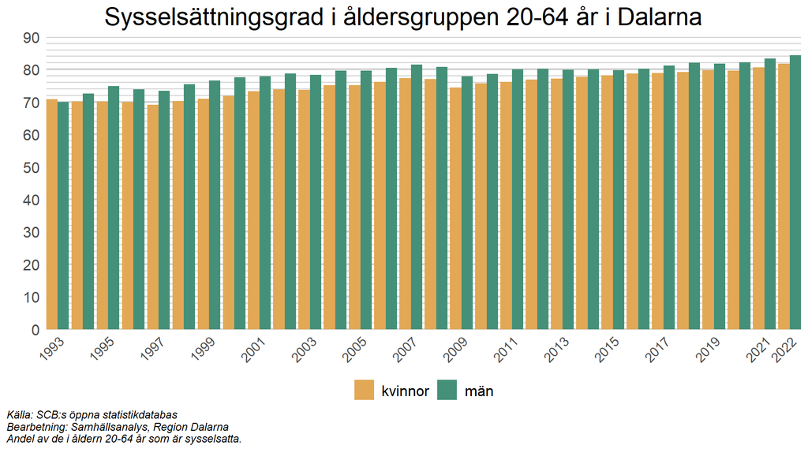

Figur 34.

Grafen nedan visar arbetslösheten i Sverige och Dalarna under perioden 2008 till 2023. Andelen arbetslösa i Dalarna (de mörkgröna staplarna) har konsekvent varit lägre än andelen arbetslösa i Sverige (de ljusgröna staplarna). Sedan pandemin har andelen arbetslösa i både Sverige och Dalarna sjunkit, och 2023 var arbetslösheten i genomsnitt 6,4 respektive 5,8 procent. Under andra kvartalet 2024 var arbetslösheten i Dalarna 5,3 procent, att jämföra med 6,5 procent för riket som helhet ([Arbetsförmedlingen, 2024](https://mb.cision.com/Public/1326/4016890/945db14fdac19df6.pdf)).

Dalarnas låga arbetslöshet beror till viss del på att:

- Dalarna har en mångsidig ekonomi med olika industrier och sektorer, vilket kan minska sårbarheten för arbetslöshet. Om en sektor drabbas av nedgång kan andra sektorer fortfarande erbjuda möjligheter till sysselsättning ([Region Dalarna, 2022](https://www.regiondalarna.se/contentassets/d845727dbc9f49c3b7b09a2c60456497/socioekonomisk-analys-2022-nms.pdf); [Teknikföretagen, 2019](https://www.teknikforetagen.se/globalassets/rapporter--publikationer/ekonomisk-analys/hjartat-i-svensk-ekonomi/hjartat-i-svensk-ekonomi---industrins-betydelse-och-villkor-i-dalarnas-lan.pdf)).
- En aktiv och stark arbetsmarknad, med företag som skapar nya arbetstillfällen och expansion av befintliga företag, kan bidra till att minska arbetslösheten ([Arbetsförmedlingen, 2024](https://arbetsformedlingen.se/download/18.210b3bc318fa36ad8ec193e/1718203233372/regionala-utsikter-varen-2024.pdf)).
- Dalarna har goda kommunikationsmöjligheter och närhet till städer med hög ekonomisk aktivitet, vilket kan öka möjligheterna till arbete och affärsmöjligheter ([Region Dalarna, 2021](https://www.regiondalarna.se/globalassets/regional-utveckling/dalastrategin-2030-tillsammans-for-ett-hallbart-dalarna-dec.pdf/)).
- Det finns stöd för lokala företag, vilket stimulerar ekonomin och skapar fler arbetstillfällen (Se [Region Dalarna, Företagsstöd](https://www.regiondalarna.se/verksamhet/regional-utveckling/projektmedel-stod-och-bidrag/foretagsstod/)).

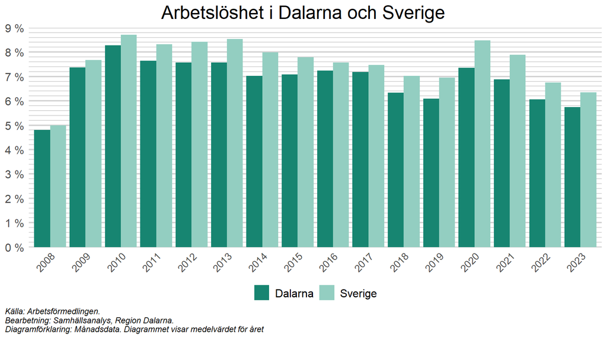

Figur 35.

## 4.2 Matchning på arbetsmarknaden

Nivån av matchning på arbetsmarknaden mäter i hur stor utsträckning människor jobbar med vad de är utbildade till. Generellt tenderar olika typer av specialiserade eftergymnasiala utbildningar, exempelvis läkare och psykologer, ha hög matchning. Utbildar man sig till läkare är det väldigt hög sannolikhet att man även har det som yrke (över 90 procent). På andra sidan av spektrumet finns dels olika former av gymnasieutbildningar, dels eftergymnasiala utbildningar inom exempelvis humaniora och konst, där runt hälften jobbar med vad de är utbildade till.

I stora drag ligger matchninggraden på runt 73 procent för kvinnor och 70 procent för män i Sverige. Det finns vissa skillnader mellan länen, men dessa är relativt små. I Dalarna är matchningsgraden cirka 72 procent för kvinnor och 68 för män , vilket alltså är marginellt lägre än riket som helhet.

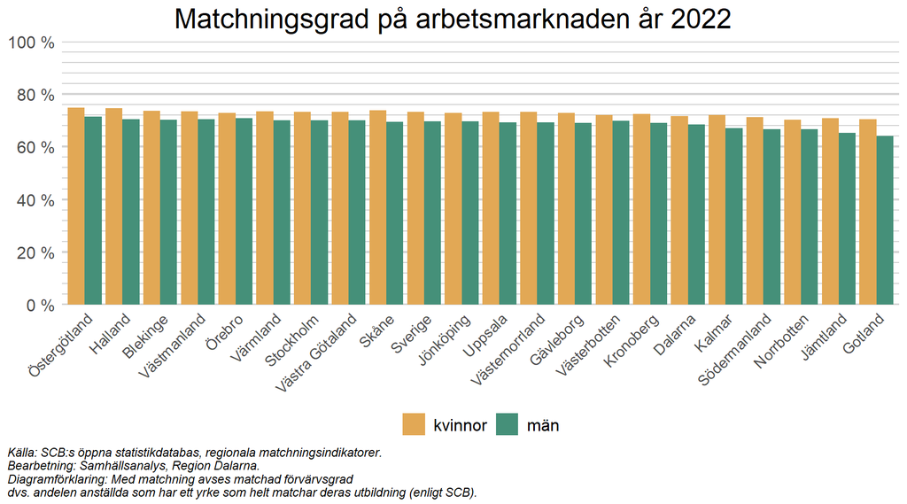

Figur 36.

Matchningen på arbetsmarknaden tenderar att variera beroende på var man är född. I Dalarna har inrikes födda högst matchning med 72 procent för kvinnor och 69 procent för män. Lägst matchningsgrad för män har personer födda i Afrika (cirka 59 procent), medan personer födda i Norden eller EU utom Sverige har lägst matchningsgrad för kvinnor (cirka 68 procent). Kvinnor födda i Afrika är dock den kategori i diagrammet nedan som har högst matchningsgrad med knappt 76 procent.

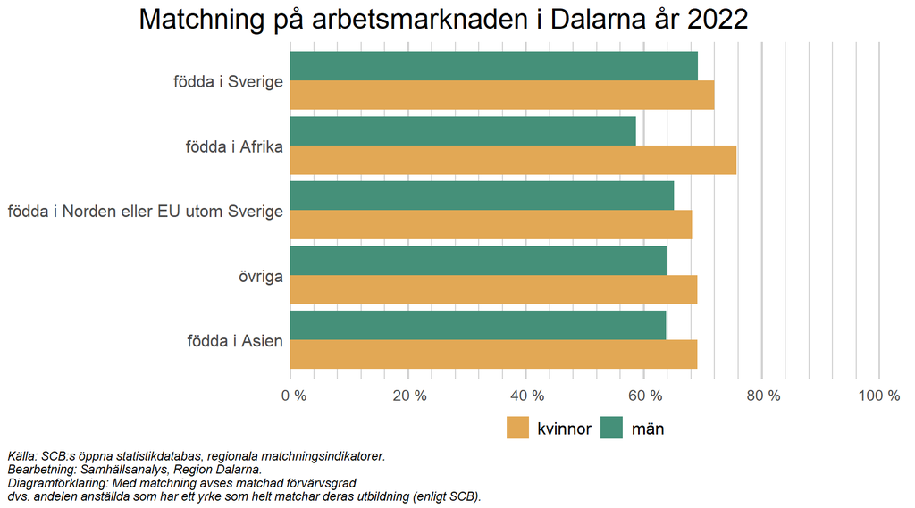

Figur 37.

## 4.3 Brist på arbetskraft och kompetens

Ytterligare en viktig aspekt av arbetsmarknaden är hur lätt det är för arbetsgivare att hitta arbetskraft med rätt kompetens. Bland Sveriges län varierar den upplevda bristen på arbetskraft relativt mycket. Lättast att hitta kompetens år 2023 har småföretag i Östergötland, där ungefär 20 procent av småföretagen uppger att de har brist på kompetens, att jämföra med Norrbotten, där ungefär 45 procent av småföretagen uppger att de har samma brist. I Dalarna upplever ungefär 41 procent av småföretagarna att de har svårt att hitta arbetskraft, vilket är en ökning med 13 procentenheter sedan undersökningen som gjordes 2020.

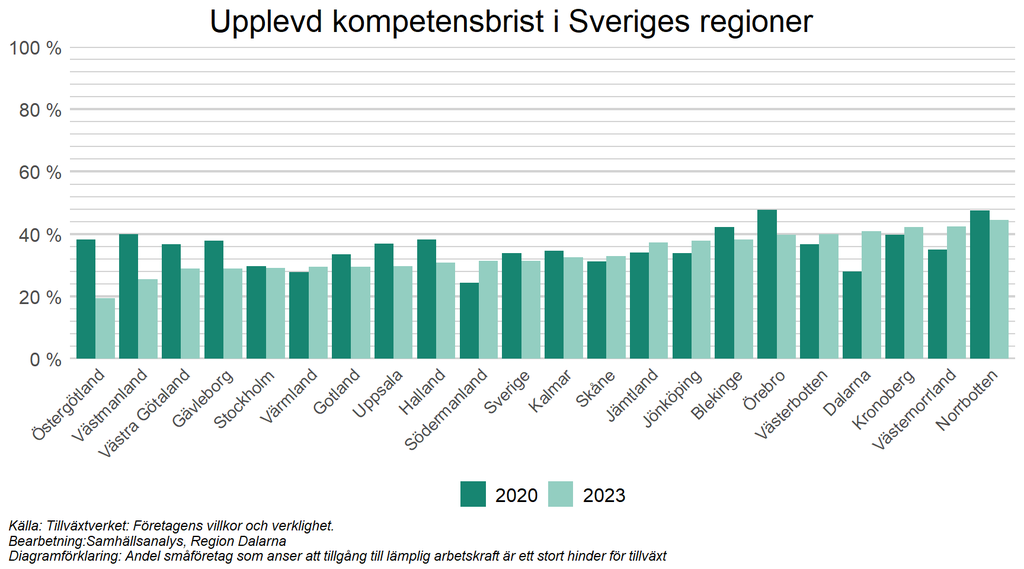

Figur 38.

Det finns en underliggande svårighet i att separera bristen på arbetskraft från bristen på kompetens. En situation med allt färre i arbetsför ålder skapar en generell brist på arbetskraft, men den förstärker sannolikt även bristen på kompetens då arbetskraftsreserven minskar. Arbetsgivarna behöver därför anställa individer som står längre från de kompetenskrav som ställs, vilket ökar behovet av vidareutbildning efter anställning. För ett djupare resonemang om dessa två brister och potentiella lösningar hänvisas till [Tillväxtanalys, 2024](https://www.tillvaxtanalys.se/publikationer/rapport/rapportserien/2024-02-29-arbetskrafts--och-kompetensbrist.html/).

# 5 Sammanfattande diskussion

Arbetsmarknaden och kompetensförsörjningen i Dalarna är komplex med flera utmaningar som samspelar. Dessa utmaningar inkluderar en åldrande befolkning, minskat arbetskraftsutbud, ökande kompetenskrav och svårigheter att matcha arbetskraftens kvalifikationer med efterfrågan från arbetsgivare.

* **Arbetskraftsefterfrågan**  
Arbetskraftsefterfrågan i form av lediga jobb i Dalarna har ökat markant de senaste decennierna. Det är privat sektor som står för majoriteten av de lediga jobben, även om offentlig sektor också haft en betydande efterfrågeökning. Den totala efterfrågan är dock svår att prognostisera och påverkas av faktorer som ekonomiska trender och teknologiska förändringar. Det finns även en variation i efterfrågan på arbetskraft, beroende på bransch och region. Till exempel har hotell- och restaurangbranschen ett stort behov av enklare arbetskraft, medan andra sektorer, såsom IT och offentlig förvaltning, efterfrågar högre kvalifikationer. Cirka två tredjedelar av alla lediga jobb tillsätts med personer som redan är förvärvsarbetande, så kallade jobbytare. Det förhållandet har varit relativt konstant över tid.

* **Kompetens och kvalifikationskrav**  
En viktig aspekt av arbetsmarknaden är hur arbetsgivare efterfrågar olika nivåer av kompetens. I Dalarna finns det stora skillnader i vilka typer av jobb som dominerar och därmed också skillnader i kvalifikationskrav. Sektorer som vård och omsorg samt utbildning kräver ofta högre utbildning, medan andra, såsom hotell- och restaurang, främst efterfrågar arbetskraft med enklare kvalifikationer. Det finns stora variationer inom och mellan regioner i efterfrågan på gymnasial och högre utbildning. Dalarna har en hög andel yrken som kräver gymnasial kompetens, medan Stockholms län har flest jobb med krav på högskoleutbildning.

* **Brist på arbetskraft och kompetens**  
Det finns en utbredd uppfattning om kompetensbrist bland arbetsgivare, särskilt inom småföretag. I Dalarna upplever omkring 41 procent av småföretagen svårigheter att hitta rätt kompetens, vilket är en ökning med 13 procentenheter från tidigare år. Bristen på arbetskraft förstärks av att den totala arbetskraftsreserven minskar, vilket gör det svårt för arbetsgivare att hitta kvalificerade kandidater. Detta kan vara särskilt påtagligt inom vissa sektorer och yrken, vilket kan hämma ekonomisk tillväxt och innovation. För att hantera detta måste arbetsgivarna ofta sänka kompetenskraven och investera i vidareutbildning. Alternativet är att vidta strukturella förändringar för att anpassa sig till den förändrade demografiska profilen. Det kan innebära ökad efterfrågan på teknologiska lösningar, automation och andra effektiviseringsåtgärder för att kompensera för bristen på arbetskraft.

* **Arbetskraftsutbudet**  
Utbudet av arbetskraft minskar, främst på grund av en åldrande befolkning och ett negativt inrikes flyttnetto i många delar av Dalarna. Mellan 2002 och 2022 minskade antalet inrikes födda i arbetsför ålder med cirka 20 000 personer, och även om antalet utrikes födda har ökat, har detta inte varit tillräckligt för att kompensera för förlusten.

Det finns en tydlig skillnad i sysselsättningsgraden mellan inrikes och utrikes födda och andelen utrikes födda av den totala befolkningen i arbetsför ålder ökar. För att möta den arbetskrafts- och kompetensbrist som råder är en viktig del att fortsatt öka sysselsättningsgraden för utrikes födda. Det långsiktiga utbudet påverkas av förändringar i utbildningsnivåer, pendlingsmönster och migration, men den ökade andelen äldre innebär också ett större behov av arbetskraft inom vård och omsorg, något som framstår som en kritisk utmaning. Dalarna har en relativt låg andel högskoleutbildade invånare, vilket arbetsgivarna behöver förhålla sig till. Om det finns stora krav på högskoleutbildning kommer ett gap mellan efterfrågan och utbud att uppstå.

* **Arbetsmarknadens åldersstruktur**  
En annan viktig faktor är åldersstrukturen inom olika sektorer. Särskilt inom vård och omsorg, men även i tillverkningssektorn, är en stor del av arbetskraften över 50 år, vilket innebär att många kommer att gå i pension inom de närmaste 15-20 åren. Detta, i kombination med att befolkningen i Dalarna blir allt äldre, innebär ett stort framtida rekryteringsbehov inom dessa sektorer. Särskilt vården står inför en allvarlig situation där efterfrågan på tjänster ökar samtidigt som tillgången på arbetskraft minskar. Med en ökande andel äldre människor ökar behovet av hälso- och sjukvård, äldreomsorg samt pensioner. Detta ökar belastningen på sociala trygghetssystem och offentliga finanser, genom investeringar och anpassningar inom hälso- och sjukvårdssystemet, om behoven hos den äldre befolkningen ska mötas.

* **Matchningen på arbetsmarknaden**  
En central utmaning är matchningen mellan utbud och efterfrågan på arbetskraft. I Dalarna är sysselsättningsgraden högre än riksgenomsnittet, men det finns stora skillnader mellan inrikes och utrikes födda. Sysselsättningsgraden är generellt sett lägre för utrikes födda, vilket till stor del kan bero på lägre utbildningsnivå och svårigheter att anpassa sig till arbetsmarknadens krav. Matchningen försvåras också av skillnader mellan kvinnor och män, där kvinnor i högre grad arbetar inom vård, omsorg och utbildning medan män är överrepresenterade inom bygg- och tillverkningssektorerna. Dessutom tenderar utrikes födda att ha svårare att få jobb som motsvarar deras utbildning, vilket försvårar integrationen på arbetsmarknaden.

* **Avslutande kommentar**  
Avslutningsvis är kompetensförsörjningen i Dalarna en av de största utmaningarna för länets framtida utveckling. Med rätt strategiska insatser och samarbete mellan offentlig sektor, näringsliv och utbildningsinstitutioner kan dock dessa utmaningar mötas på ett hållbart sätt. Det finns ett tydligt behov av att hitta nya lösningar för att hantera kompetensförsörjningsutmaningarna. Teknologisk utveckling, förändrade arbetsmarknadsstrukturer och en åldrande befolkning ställer höga krav på utbildningssystemet och arbetsmarknadsinsatser. För att uppnå långsiktig hållbarhet och uppfylla målen i Dalastrategin 2030, måste aktörer inom Dalarna satsa på att förbättra matchningen mellan utbildning och arbetsmarknadsbehov, samt underlätta för unga och utrikes födda att integreras på arbetsmarknaden.